# lime

## Algorithm preparation

I've decided to use three images describing peking duck, paella and panna cotta. I divided each of them in 49 regions like on image:

[figure not shown]

## Generating subimages and calculating predictions for them

I generated subimages by drawing vector of size number of regions from uniform distribution and graying out certain super-pixel if it is above 0.5 threshold:

[figure not shown]

The image with grayed-out super pixels is `z` from the paper and boolean vector (mapped later to float) indicating if super-pixel is chosen is `z'` from the LIME paper. I calculated predictions `f(z)` just by using my clasifier on each subimage.

## Calculating LIME explanaitions

Explanation `g` is a function from the `z'` space to reals described by dot product of `z'` and some weights `w` so to calculate explanaitions I need to calculate theese weights. For this I must calculate proximity measures `pi(z)` so I calculate them using the equation from the LIME paper and I have whole set `Z` from the paper by now.

I fixed constance `K` to 10 and made `K`-Lasso writen in the paper which is selecting `K` features (`z'`'s are features here) using Lasso with regularization and then learned the weights for non-zero features `z'` via least squares having `f(z)`'s as targets - I used scikit-learn functions for this step.

Then explanaitions `g` can be implemented, becouse they have this weights internally.

## Remark

Most variables in scripts in appendix are dicts with keys being image names. Just provide image name in `[]` to get access to variable for image of interest.

## Explanations visualization

I have visualized obtained explanations after rescailing their values (red are for negative values, green for positive).

### Explanation for peking duck

[figure not shown]

### Explanation for paella

[figure not shown]

### Explanation for panna cotta

[figure not shown]

# Appendix

## Used library imports

```python
from sklearn.linear_model import Lasso
from sklearn.linear_model import LinearRegression
from transformers import pipeline
import matplotlib.pyplot as plt
from PIL import Image
import numpy as np
from copy import deepcopy
```

## Initial data preparation and constances initialization

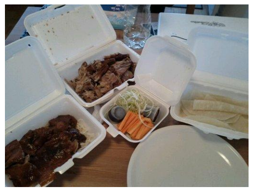

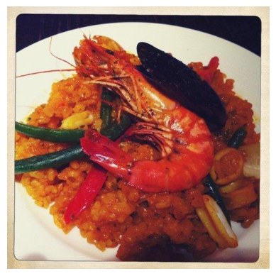

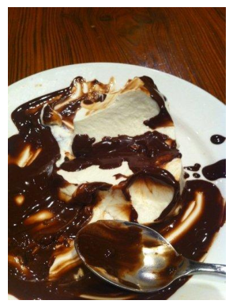

```python
class ImageName:
    PEKING_DUCK = 'peking_duck'
    PAELLA = 'paella'
    PANNA_COTTA = 'panna_cotta'

IMAGE_NAMES = [ImageName.PEKING_DUCK, ImageName.PAELLA, ImageName.PANNA_COTTA]
SELECTED_OBSERVATIONS = {image_name: Image.open(f'{image_name}.jpg') for image_name in IMAGE_NAMES}
CHOSEN_VISION_MODEL = "Shresthadev403/food-image-classification"
TASK = "image-classification"
DEVICE = "cuda"
SELECTED_NUMBER_OF_REGIONS = 49
N = 100
K = 10


for observation in SELECTED_OBSERVATIONS.values():
    plt.axis('off'); plt.imshow(observation); plt.show()
```

## Calculate the predictions for selected observations

```python
pipe = pipeline(TASK, device=DEVICE, model=CHOSEN_VISION_MODEL)
```

[output not shown]

```python
def calculate_the_predictions_for_selected_observations(pipe, observations):
    pipe = pipeline(TASK, device=DEVICE, model=CHOSEN_VISION_MODEL)
    best_predictions = {
        image_name: predictions[0]
            for image_name, predictions
                in zip(SELECTED_OBSERVATIONS.keys(), pipe(list(SELECTED_OBSERVATIONS.values())))
        }
    return best_predictions

predictions_for_observations = calculate_the_predictions_for_selected_observations(pipe, SELECTED_OBSERVATIONS)
predictions_for_observations
```

```
{'peking_duck': {'label': 'peking_duck', 'score': 0.9999865293502808},
 'paella': {'label': 'paella', 'score': 0.9999983310699463},
 'panna_cotta': {'label': 'panna_cotta', 'score': 0.9999784231185913}}
```

## Divide images in grids of rectangles

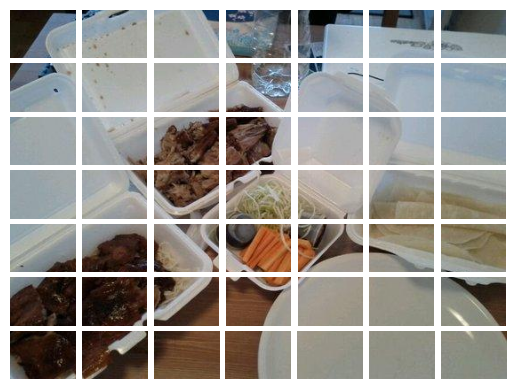

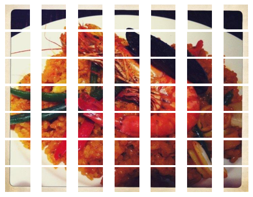

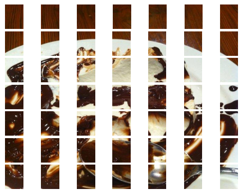

```python
class GridOfRectangles:
    """Class for calculating regions"""
    def __init__(self, image, number_of_regions: int):
        self.number_of_regions = number_of_regions
        self.h, self.w = self.get_sides()
        self.array = self.calculate_regions(image)

    def get_sides(self):
        """Chooses grid dimentions for non-prime number of regions greater than 3"""
        if self.number_of_regions <= 3:
            raise ValueError(f"Provide number greater than 3")
        for i in range(int(self.number_of_regions ** 0.5 + 1), 1, -1):
            if self.number_of_regions % i == 0:
                return i, self.number_of_regions // i
        raise ValueError(f"{self.number_of_regions} is prime, provide not prime number")

    def calculate_regions(self, image):
        array = []
        parts = np.array_split(image, self.h)
        for part in parts:
            array.append(np.array_split(part, self.w, axis=1))
        return array

    def visualize(self):
        f, axs = plt.subplots(self.h, self.w)
        for i, row in enumerate(self.array):
            for j, element in enumerate(row):
                axs[i, j].imshow(element)
                axs[i, j].set_xticklabels([])
                axs[i, j].set_yticklabels([])
                axs[i, j].axis('off')

        plt.subplots_adjust(wspace=0.1, hspace=0.1)
        plt.show()

observations = {image_name: np.array(observation) for image_name, observation in SELECTED_OBSERVATIONS.items()}
regions = {image_name: GridOfRectangles(image, SELECTED_NUMBER_OF_REGIONS) for image_name, image in observations.items()}

for region in regions.values():
    region.visualize()
```

## Generate subimages and calculate predictions for them

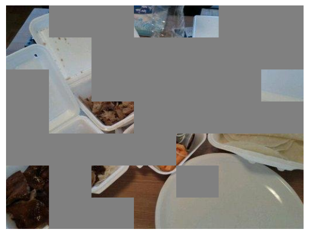

```python
def generate_sample_in_interpretable_representation():
    return np.random.random_sample(size=SELECTED_NUMBER_OF_REGIONS) < 0.5

def generate_gray_rectangle(h, w):
    return np.full((h, w, 3), 128, dtype=np.uint8)

def calculate_subimage_score(subimage_prediction, label):
    for pred in subimage_prediction:
        if pred['label'] == label:
            return pred['score']
    return 0.

z_prims = {
    ImageName.PEKING_DUCK: [generate_sample_in_interpretable_representation() for _ in range(N)],
    ImageName.PAELLA: [generate_sample_in_interpretable_representation() for _ in range(N)],
    ImageName.PANNA_COTTA: [generate_sample_in_interpretable_representation() for _ in range(N)]
}

zs = {
    image_name: [
        np.concatenate([
            np.concatenate([
                element if selected[i * grid.w + j]
                    else generate_gray_rectangle(element.shape[0], element.shape[1])
                    for j, element in enumerate(row)
            ], axis=1) for i, row in enumerate(grid.array)
        ])
        for selected in z_prims[image_name]
    ] for image_name, grid in regions.items()
}

z_prims = {k: np.array(z_prim).astype(float) for k, z_prim in z_prims.items()}

f_zs = {
    k:  np.array([
        calculate_subimage_score(pipe(Image.fromarray(z)), predictions_for_observations[k]['label'])
            for z in zs[k]
        ])
        for k in zs.keys()
}

plt.axis('off')
plt.imshow(zs[ImageName.PEKING_DUCK][0])
plt.show()
```

## Calculate LIME explanations

```python
def get_pi(x):
    def D(x, z):
        return np.sum((x.astype(np.int64) - z.astype(np.int64)) ** 2) ** 0.5
    sigma = x.shape[1]
    return lambda z: np.exp(-D(x, z) / (sigma ** 2))

def k_lasso(z_prims, f_z, k, alpha=0.1):
    lasso_model = Lasso(alpha=alpha)
    lasso_model.fit(z_prims, f_z)
    coefs = np.abs(lasso_model.coef_)
    top_k_features = np.argsort(coefs)[-k:]
    res = np.zeros(shape=(z_prims.shape[1],), dtype=bool)
    res[top_k_features] = True
    return res

pi_x = {k: get_pi(x) for k, x in observations.items()}
pi_zs = {k: [pi_x[k](z) for z in zs[k]] for k in zs.keys()}
```

```python
selected_features_mask = {image_name: k_lasso(z_prim, f_zs[image_name], K) for image_name, z_prim in z_prims.items()}
selected_features = {image_name: z_prims[image_name][:, mask] for image_name, mask in selected_features_mask.items()}

w = {image_name: np.zeros(shape=(SELECTED_NUMBER_OF_REGIONS,), dtype=float) for image_name in selected_features.keys()}

for image_name, features in selected_features.items():
    model = LinearRegression()
    model.fit(features, f_zs[image_name])
    w[image_name][selected_features_mask[image_name]] = model.coef_

g = {
    image_name: (lambda z_prim: np.sum(w_g * z_prim)) for image_name, w_g in w.items()
}
```

## Visualize explanaitions

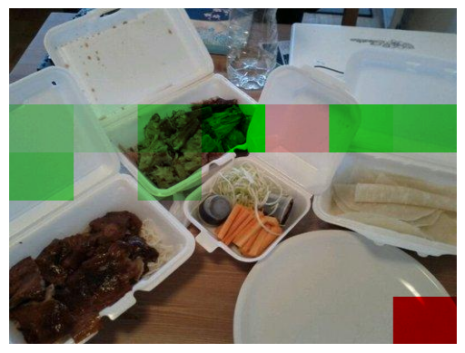

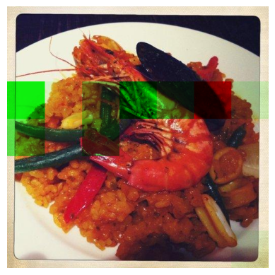

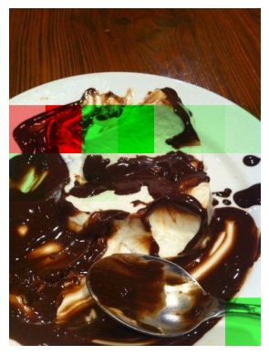

```python
spaced_weights = np.array([weight.reshape(region.h, region.w) for weight, region in zip(w.values(), regions.values())])
positive_weights = spaced_weights.copy(); positive_weights[positive_weights < 1e-16] = 0
negative_weights = -spaced_weights.copy(); negative_weights[negative_weights < 1e-16] = 0
positive_rescaled = (positive_weights - positive_weights.min(axis=(1, 2))[:, None, None]) / (positive_weights.max(axis=(1, 2))[:, None, None] - positive_weights.min(axis=(1, 2))[:, None, None])
negative_rescaled = (negative_weights - negative_weights.min(axis=(1, 2))[:, None, None]) / (negative_weights.max(axis=(1, 2))[:, None, None] - negative_weights.min(axis=(1, 2))[:, None, None])

def apply_influence(element, idx, i, j):
    positive = np.full_like(element, positive_rescaled[idx, i, j], dtype=float)
    negative = np.full_like(element, negative_rescaled[idx, i, j], dtype=float)
    positive[:, :, [0, 2]] = 0; negative[:, :, [1, 2]] = 0
    influence = positive + negative
    return element * (1 - positive_rescaled[idx, i, j] - negative_rescaled[idx, i, j]) + element * influence

influences = [
    np.concatenate([
        np.concatenate([
            apply_influence(element, idx, i, j)
                for j, element in enumerate(row)
        ], axis=1) for i, row in enumerate(grid.array)
    ]).astype(np.uint8)
    for idx, (image_name, grid) in enumerate(regions.items())
]

for influence in influences:
    plt.axis('off')
    plt.imshow(influence)
    plt.show()
```